# Project 1

Valentino Djaja Sastra

9/14/2021

## Loading and preprocessing the data

```r
# Download the data & unzip
fileURL = "https://d396qusza40orc.cloudfront.net/repdata%2Fdata%2Factivity.zip"
download.file(fileURL, destfile ="./Data.zip")
unzip(zipfile="./Data.zip")

# Read csv into R data frame
data_vec <- read.csv("activity.csv", header = TRUE)
data_vec$day <- weekdays(as.Date(data_vec$date))
data_vec$DateTime<- as.POSIXct(data_vec$date, format="%Y-%m-%d")

# Subset data without NA into clean_data data frame
clean_data <- data_vec[!is.na(data_vec$steps),]

# Convert data frame into a tibble
library(tibble)
df <- as_tibble(clean_data)
```

## What is the mean total number of steps taken per day?

```r
# Compute total number of steps by date
library(dplyr)
df_sum <- df %>% group_by(date) %>%
          dplyr::summarize(steps = sum(steps, na.rm = TRUE)) %>%
          arrange(date)
```

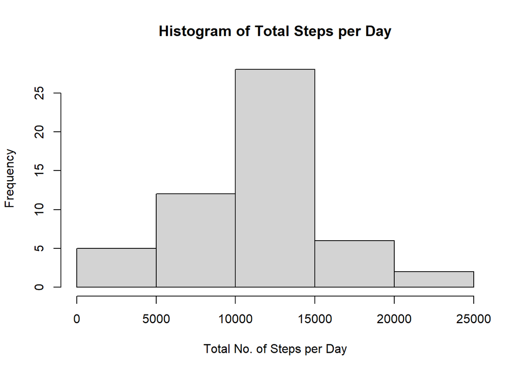

```r
# Plot histogram
str1 = "Total No. of Steps per Day"
str2 = "Histogram of Total Steps per Day"
hist(df_sum$steps, xlab = str1, main = str2)
```

```r
# Generate mean & median of total no. of steps per day
b <- as.integer(round(summarize(df_sum,
          avg_steps = mean(steps, na.rm = TRUE),
          median_steps = median(steps, na.rm = TRUE))))

names(b) <- c("avg_steps", "median_steps")
print(b)
```

```
##    avg_steps median_steps
##        10766        10765
```

- Mean of total number of steps taken per day: 10766 steps
- Median of total number of steps taken per day: 10765 steps

## What is the average daily activity pattern?

Make a time series plot (i.e. type = “l”) of the 5-minute interval (x-axis) and the average number of steps taken, averaged across all days (y-axis)

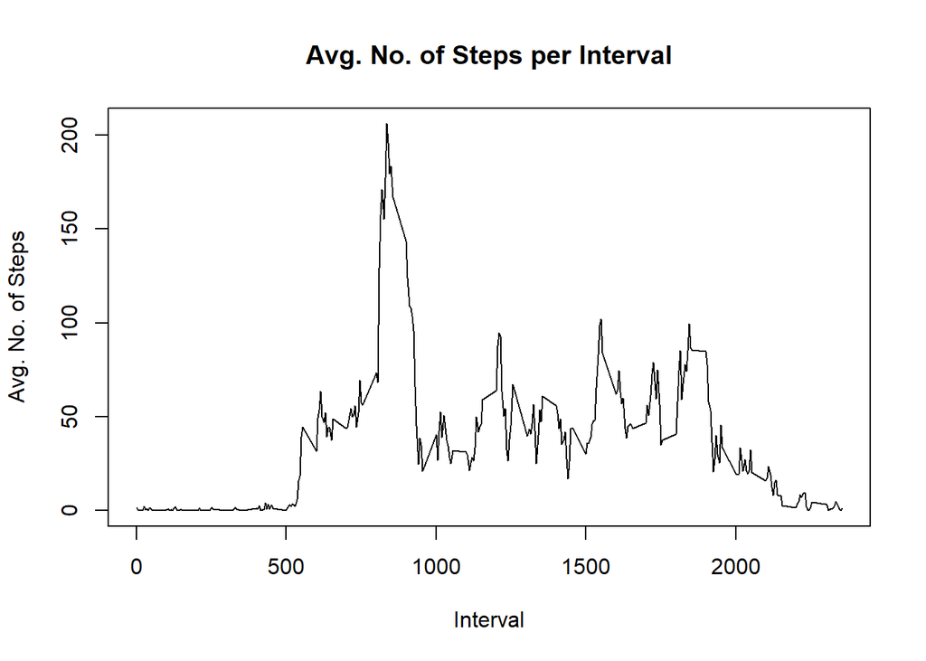

```r
# Compute mean of steps by interval
df2 <- df %>% group_by(interval) %>% dplyr::summarize(avg_steps = mean(steps))

# Generate plot of average no. of steps vs interval
with(df2, plot(interval, avg_steps,
               xlab = "Interval",
               ylab = "Avg. No. of Steps",
               main = "Avg. No. of Steps per Interval",
               type = "l"))
```

```r
# Calculate maximum avg. no. of steps and corresponding interval
max_steps <- round(max(df2$avg_steps))
max_interval <- df2[df2$avg_steps == max(df2$avg_steps), 1]
```

- The maximum number of steps for a 5-minute interval was 206 steps.
- The 5-minute interval which had the maximum number of steps was 835 interval.

## Imputing missing values

Number of NA entries:

```r
NA_counter <- sum(is.na(data_vec$steps))
```

Total number of rows with steps = “NA” is 2304

NAs of missing steps will be substituted with the average 5-minute interval *based on the day of the week*.

```r
# Generating new data with imputed NAs values in steps
df3 <- df %>% group_by(interval, day) %>% dplyr::summarize(avg_steps = mean(steps))
nadata <- as_tibble(data_vec[is.na(data_vec$steps),])
newdata <- merge(nadata, df3, by = c("interval", "day"))
newdata2 <- select(newdata, steps = avg_steps, date, interval, day, DateTime)
new_master <- arrange(rbind(df, newdata2), DateTime)
```

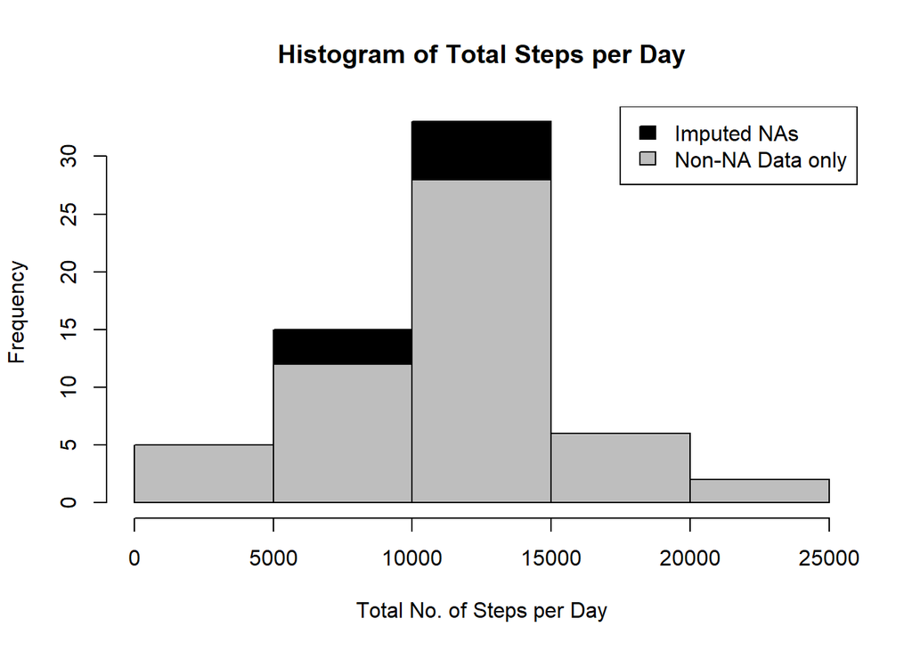

```r
# Generating histogram of comparisons
df_sum_new <- new_master %>% group_by(date) %>%
            dplyr::summarize(steps = sum(steps, na.rm = TRUE)) %>%
            arrange(date)
str1 = "Total No. of Steps per Day"
str2 = "Histogram of Total Steps per Day"
hist(df_sum_new$steps, xlab = str1, main = str2, col = "Black")
hist(df_sum$steps, xlab = str1, main = str2, col = "Grey", add = TRUE)
legend("topright", c("Imputed NAs", "Non-NA Data only"), fill = c("black", "grey"))
```

```r
# Compute new mean and median with NA adjustments
c <- as.integer(round(summarize(df_sum_new,
          avg_steps = mean(steps, na.rm = TRUE),
          median_steps = median(steps, na.rm = TRUE))))

names(c) <- c("avg_steps", "median_steps")
print(c)
```

```
##    avg_steps median_steps
##        10821        11015
```

With NAs adjustments:

- Mean of total number of steps taken per day: 10821 steps
- Median of total number of steps taken per day: 11015 steps

## Are there differences in activity patterns between weekdays and weekends?

```r
# Generate new column to identify weekend or weekdays
new_master$DayCat <- ifelse(new_master$day %in% c("Saturday", "Sunday"), "Weekend", "Weekday")
```

```r
# Summarize data by Day Category (weekend/weekdays) and interval
df_sum_3 <- new_master %>% group_by(interval, DayCat) %>% dplyr::summarize(avg_steps = mean(steps))
```

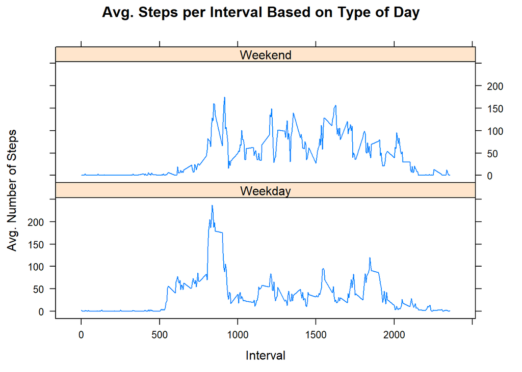

```r
# Plot comparison of no. of steps between weekend and weekdays
library(lattice)
xyplot(avg_steps ~ interval | DayCat, data = df_sum_3, type="l",  layout = c(1,2),
       main="Avg. Steps per Interval Based on Type of Day",
       ylab="Avg. Number of Steps", xlab="Interval")
```

Yes, the step activity trends differ between weekdays and weekends. This is possibly due to different time windows and opportunity levels of activity between the two periods.